# Website User Conversion Rate

25/05/2022

knitr::purl(input = “w.Rmd”, output = “w.R”, documentation = 0)

```r
#install.packages("tidyverse")
#install.packages("broom")
#install.packages("pROC")
#install.packages("dplyr")
#install.packages("forestmangr")
#install.packages("ggplot2")
#install.packages("ggmosaic")
#install.packages("ggpubr")
```

Install the packages

```r
library(tidyverse)
library(forestmangr)
library(broom)
library(dplyr)
library(pROC)
```

```r
library(ggplot2)
library(ggmosaic)
library(ggpubr)
```

Load the packages

# Question-1) Read and inspect the data set. Provide a descriptive analysis for each of the variables in the data set.

```r
ecommerce <- read.csv("ecommerce.csv")
summary(ecommerce)
```

```
##    discount          conversion           source          total_pages_visited
##  Length:25046       Length:25046       Length:25046       Min.   : 1.000
##  Class :character   Class :character   Class :character   1st Qu.: 3.000
##  Mode  :character   Mode  :character   Mode  :character   Median : 4.000
##                                                           Mean   : 4.344
##                                                           3rd Qu.: 6.000
##                                                           Max.   :16.000
##  visit_duration     country
##  Min.   : 55.87   Length:25046
##  1st Qu.:177.86   Class :character
##  Median :241.19   Mode  :character
##  Mean   :260.68
##  3rd Qu.:354.39
##  Max.   :977.25
```

```r
glimpse(ecommerce)
```

```
## Rows: 25,046
## Columns: 6
## $ discount            <chr> "no", "no", "no", "no", "no", "no", "no", "no", "n~
## $ conversion          <chr> "no", "no", "no", "no", "no", "no", "no", "no", "n~
## $ source              <chr> "direct", "direct", "direct", "direct", "direct", ~
## $ total_pages_visited <int> 3, 6, 3, 6, 7, 1, 4, 7, 4, 4, 8, 4, 5, 4, 2, 7, 3,~
## $ visit_duration      <dbl> 179.50673, 356.98638, 181.38014, 368.17220, 408.97~
## $ country             <chr> "france", "germany", "uk", "uk", "germany", "germa~
```

Import the data set and execute summary and glimpse

There are 6 variables in the dataset and target variable is conversion The target variable is binary so we proceed with logistic regression

# Question-2) Build a simple logistic regression model of conversion on discount.Call this model m1. Comment on the coefficient estimate of discountyes. What is the sign of the coefficient? Is the effect statistically significant?

```r
ecommerce <- ecommerce %>% mutate(conversion = factor(conversion), discount = factor(discount), source = factor(source), country = factor(country))
```

Categorical variables converted into factor form for modelling

```r
m1 <- glm(conversion ~ discount, data = ecommerce, family = binomial)
```

```r
summary(m1)
```

```
##
## Call:
## glm(formula = conversion ~ discount, family = binomial, data = ecommerce)
##
## Deviance Residuals:
##     Min       1Q   Median       3Q      Max
## -0.8681  -0.5323  -0.5323  -0.5323   2.0121
##
## Coefficients:
##             Estimate Std. Error z value Pr(>|z|)
## (Intercept) -1.88262    0.02142  -87.89   <2e-16 ***
## discountyes  1.10090    0.03504   31.41   <2e-16 ***
## ---
## Signif. codes:  0 '***' 0.001 '**' 0.01 '*' 0.05 '.' 0.1 ' ' 1
##
## (Dispersion parameter for binomial family taken to be 1)
##
##     Null deviance: 23300  on 25045  degrees of freedom
## Residual deviance: 22352  on 25044  degrees of freedom
## AIC: 22356
##
## Number of Fisher Scoring iterations: 4
```

Co-efficient of discountyes is positive and it is statistically significant as p-value is less than 0.05

# Question-3) Calculate the odds ratio for discountyes. What does this mean?

```r
exp(coef(m1))
```

```
## (Intercept) discountyes
##    0.152191    3.006872
```

The odds ratio of discount yes is 3.006872

# Question-4) Calculate the 95% confidence interval for the odds ratio for discountyes. What does this mean?

```r
exp(confint(m1))
```

```
##                 2.5 %    97.5 %
## (Intercept) 0.1459018 0.1586826
## discountyes 2.8071755 3.2205543
```

The odds ratio for the discountyes is to be in the range of [2.80, 3.22]

# Question-5) Generate a double-decker mosaic plot (using the ggmosaic package) to visualise the count of the combinations of the following variables: discount (on x-axis), conversion (as fill colour), and source (as facets). Use the plot to describe whether (and how) the effect of discount on conversion is different for the three source channels.

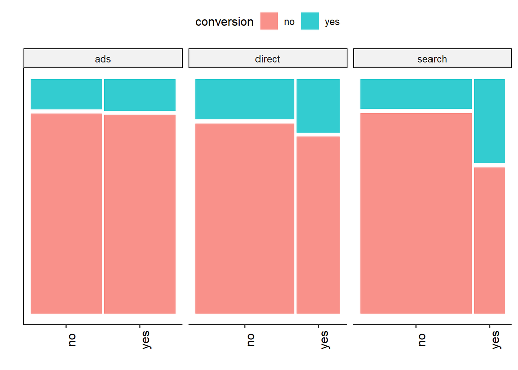

```r
ggplot(data = ecommerce) +
  geom_mosaic(aes(
    x = product(discount),
    fill = conversion),
    offset = 0.02,
    divider = ddecker()) +
  facet_grid(~source,
             scales = "free") +
  theme_pubr() +
  theme(axis.text.y = element_blank(),
        axis.ticks.y = element_blank(),
        axis.text.x = element_text(angle = 90)) +
  labs(x = "", y = "")
```

# The conversion through source direct and search is higher when discount is given

# Question-6) Build a logistic regression model that predicts conversion from discount and source. Call this model m2. Comment on the coefficient estimates of sourcedirect and sourcesearch.

```r
m2 <- glm(conversion ~ discount + source, data = ecommerce, family = binomial)
summary(m2)
```

```
##
## Call:
## glm(formula = conversion ~ discount + source, family = binomial,
##     data = ecommerce)
##
## Deviance Residuals:
##     Min       1Q   Median       3Q      Max
## -0.9032  -0.5396  -0.5396  -0.5291   2.3075
##
## Coefficients:
##              Estimate Std. Error z value Pr(>|z|)
## (Intercept)  -2.58993    0.07725 -33.527  < 2e-16 ***
## discountyes   1.16772    0.03578  32.633  < 2e-16 ***
## sourcedirect  0.69434    0.08968   7.743 9.73e-15 ***
## sourcesearch  0.73645    0.07646   9.632  < 2e-16 ***
## ---
## Signif. codes:  0 '***' 0.001 '**' 0.01 '*' 0.05 '.' 0.1 ' ' 1
##
## (Dispersion parameter for binomial family taken to be 1)
##
##     Null deviance: 23300  on 25045  degrees of freedom
## Residual deviance: 22246  on 25042  degrees of freedom
## AIC: 22254
##
## Number of Fisher Scoring iterations: 4
```

Both the variables asked are statistically significant and both of them have positive co-efficient

# Question-7) Calculate the odds ratios for sourcedirect and sourcesearch. What do these mean?

```r
exp(coef(m2))
```

```
##  (Intercept)  discountyes sourcedirect sourcesearch
##   0.07502533   3.21464165   2.00238016   2.08849965
```

The odds ratio of source direct is 2.0023 and source search is 2.0884

# Question-8) Build a logistic regression model that predicts conversion from discount and source and also includes their interaction. Call this model m3. Comment on the coefficient estimates of the interaction terms

```r
m3 <- glm(conversion~source + discount + discount:source, data = ecommerce, family = binomial)
summary(m3)
```

```
##
## Call:
## glm(formula = conversion ~ source + discount + discount:source,
##     family = binomial, data = ecommerce)
##
## Deviance Residuals:
##     Min       1Q   Median       3Q      Max
## -0.9508  -0.5262  -0.5228  -0.5228   2.0286
##
## Coefficients:
##                          Estimate Std. Error z value Pr(>|z|)
## (Intercept)              -1.90716    0.10265 -18.580  < 2e-16 ***
## sourcedirect              0.33881    0.11999   2.824  0.00475 **
## sourcesearch             -0.01382    0.10529  -0.131  0.89555
## discountyes               0.05222    0.14350   0.364  0.71592
## sourcedirect:discountyes  0.30445    0.17783   1.712  0.08689 .
## sourcesearch:discountyes  1.30923    0.14874   8.802  < 2e-16 ***
## ---
## Signif. codes:  0 '***' 0.001 '**' 0.01 '*' 0.05 '.' 0.1 ' ' 1
##
## (Dispersion parameter for binomial family taken to be 1)
##
##     Null deviance: 23300  on 25045  degrees of freedom
## Residual deviance: 22102  on 25040  degrees of freedom
## AIC: 22114
##
## Number of Fisher Scoring iterations: 4
```

From the model source yes has negative co-efficient comparing to model-2 and the significant variables are source direct and interaction between source search and discount yes

# Question-9) Calculate the 95% confidence intervals for the odds ratios for the interaction terms. What do these mean?

```r
exp(coef(m3))
```

```
##              (Intercept)             sourcedirect             sourcesearch
##                0.1485014                1.4032788                0.9862729
##              discountyes sourcedirect:discountyes sourcesearch:discountyes
##                1.0536104                1.3558777                3.7033361
```

```r
exp(confint(m3))
```

```
##                              2.5 %    97.5 %
## (Intercept)              0.1208069 0.1807238
## sourcedirect             1.1125652 1.7814509
## sourcesearch             0.8060343 1.2183404
## discountyes              0.7952684 1.3966197
## sourcedirect:discountyes 0.9561778 1.9205866
## sourcesearch:discountyes 2.7653813 4.9569491
```

The range of CI of source search and discount yes interaction is high and the odds ratio of this interaction is lying in the range of [2.765, 4.956]

# Question-10) Build a logistic regression model that predicts conversion from all available variables in the data set. This model should also include an interaction of the discount and source variables. Call this model m4. Which variables are significant at the 95% level? Including all the variables and interaction of discount and source for model-4

```r
m4 <- glm(conversion ~ discount + source + visit_duration + total_pages_visited + country + discount:source, data = ecommerce, family = binomial)
summary(m4)
```

```
##
## Call:
## glm(formula = conversion ~ discount + source + visit_duration +
##     total_pages_visited + country + discount:source, family = binomial,
##     data = ecommerce)
##
## Deviance Residuals:
##     Min       1Q   Median       3Q      Max
## -2.0585  -0.6016  -0.4270  -0.2860   2.7152
##
## Coefficients:
##                           Estimate Std. Error z value Pr(>|z|)
## (Intercept)              -3.962149   0.123598 -32.057  < 2e-16 ***
## discountyes               0.023803   0.152130   0.156  0.87567
## sourcedirect              0.364004   0.127385   2.858  0.00427 **
## sourcesearch             -0.026688   0.111469  -0.239  0.81078
## visit_duration            0.007858   0.003202   2.455  0.01411 *
## total_pages_visited      -0.054773   0.192265  -0.285  0.77574
## countrygermany            0.058121   0.052084   1.116  0.26447
## countryireland           -0.079920   0.067468  -1.185  0.23619
## countryuk                 0.001941   0.051152   0.038  0.96973
## discountyes:sourcedirect  0.290458   0.189867   1.530  0.12607
## discountyes:sourcesearch  1.365845   0.158033   8.643  < 2e-16 ***
## ---
## Signif. codes:  0 '***' 0.001 '**' 0.01 '*' 0.05 '.' 0.1 ' ' 1
##
## (Dispersion parameter for binomial family taken to be 1)
##
##     Null deviance: 23300  on 25045  degrees of freedom
## Residual deviance: 19339  on 25035  degrees of freedom
## AIC: 19361
##
## Number of Fisher Scoring iterations: 5
```

```r
exp(coef(m4))
```

```
##              (Intercept)              discountyes             sourcedirect
##                0.0190222                1.0240883                1.4390803
##             sourcesearch           visit_duration      total_pages_visited
##                0.9736646                1.0078893                0.9467004
##           countrygermany           countryireland                countryuk
##                1.0598430                0.9231901                1.0019433
## discountyes:sourcedirect discountyes:sourcesearch
##                1.3370399                3.9190348
```

```r
exp(confint(m4))
```

```
##                               2.5 %     97.5 %
## (Intercept)              0.01486555 0.02413899
## discountyes              0.76003789 1.38056078
## sourcedirect             1.12432377 1.85315855
## sourcesearch             0.78593392 1.21705790
## visit_duration           1.00158623 1.01423647
## total_pages_visited      0.64938800 1.37988564
## countrygermany           0.95718241 1.17401076
## countryireland           0.80849150 1.05329957
## countryuk                0.90656804 1.10787329
## discountyes:sourcedirect 0.92094485 1.93911212
## discountyes:sourcesearch 2.87391937 5.34218402
```

Like the previous model the odds ratio is highest is for the interaction between discount yes and source search which is 3.91 and the range is in between [2.87, 5.34]

# Question-11) Calculate the correlation between the two numerical variables in the dataset (total_pages_visited and visit_duration). Comment on the result. How may this affect m4?

```r
cor.test(ecommerce$total_pages_visited, ecommerce$visit_duration, method ="pearson")
```

```
##
##  Pearson's product-moment correlation
##
## data:  ecommerce$total_pages_visited and ecommerce$visit_duration
## t = 4266.7, df = 25044, p-value < 2.2e-16
## alternative hypothesis: true correlation is not equal to 0
## 95 percent confidence interval:
##  0.9992956 0.9993297
## sample estimates:
##       cor
## 0.9993129
```

The correlation between the two variables is almost 1 and when one is increased the other will also increase

# Question-12) Build another logistic regression model from m4 by removing the visit_duration variable. Call this model m5. How has the effect of total_pages_visited changed compared to m4?

```r
m5 <- glm(conversion ~ discount + source + total_pages_visited + country + discount:source, data = ecommerce,  family = binomial)
summary(m5)
```

```
##
## Call:
## glm(formula = conversion ~ discount + source + total_pages_visited +
##     country + discount:source, family = binomial, data = ecommerce)
##
## Deviance Residuals:
##     Min       1Q   Median       3Q      Max
## -2.0569  -0.6080  -0.4329  -0.2891   2.7117
##
## Coefficients:
##                           Estimate Std. Error z value Pr(>|z|)
## (Intercept)              -3.960850   0.123570 -32.054  < 2e-16 ***
## discountyes               0.025846   0.152079   0.170  0.86505
## sourcedirect              0.363022   0.127354   2.850  0.00437 **
## sourcesearch             -0.026504   0.111437  -0.238  0.81200
## total_pages_visited       0.416732   0.008591  48.509  < 2e-16 ***
## countrygermany            0.057256   0.052072   1.100  0.27153
## countryireland           -0.080368   0.067451  -1.192  0.23346
## countryuk                 0.001593   0.051142   0.031  0.97516
## discountyes:sourcedirect  0.288333   0.189801   1.519  0.12873
## discountyes:sourcesearch  1.362780   0.157975   8.627  < 2e-16 ***
## ---
## Signif. codes:  0 '***' 0.001 '**' 0.01 '*' 0.05 '.' 0.1 ' ' 1
##
## (Dispersion parameter for binomial family taken to be 1)
##
##     Null deviance: 23300  on 25045  degrees of freedom
## Residual deviance: 19345  on 25036  degrees of freedom
## AIC: 19365
##
## Number of Fisher Scoring iterations: 5
```

```r
exp(coef(m5))
```

```
##              (Intercept)              discountyes             sourcedirect
##               0.01904692               1.02618303               1.43766820
##             sourcesearch      total_pages_visited           countrygermany
##               0.97384368               1.51699643               1.05892706
##           countryireland                countryuk discountyes:sourcedirect
##               0.92277628               1.00159397               1.33420089
## discountyes:sourcesearch
##               3.90703954
```

```r
exp(confint(m5))
```

```
##                               2.5 %     97.5 %
## (Intercept)              0.01488574 0.02416909
## discountyes              0.76166626 1.38324310
## sourcedirect             1.12328279 1.85121926
## sourcesearch             0.78612338 1.21719979
## total_pages_visited      1.49177861 1.54287310
## countrygermany           0.95637775 1.17296793
## countryireland           0.80815616 1.05279218
## countryuk                0.90626919 1.10746579
## discountyes:sourcedirect 0.91911025 1.93474933
## discountyes:sourcesearch 2.86545077 5.32524297
```

The interaction between discount yes and source search is having the hightest odds ratio and lies in the range between [2.86, 5.32]

# Question-13) Make a plot that visualises the odds ratios (as points) of the variables in m5 as well as their confidence intervals (as error bars).

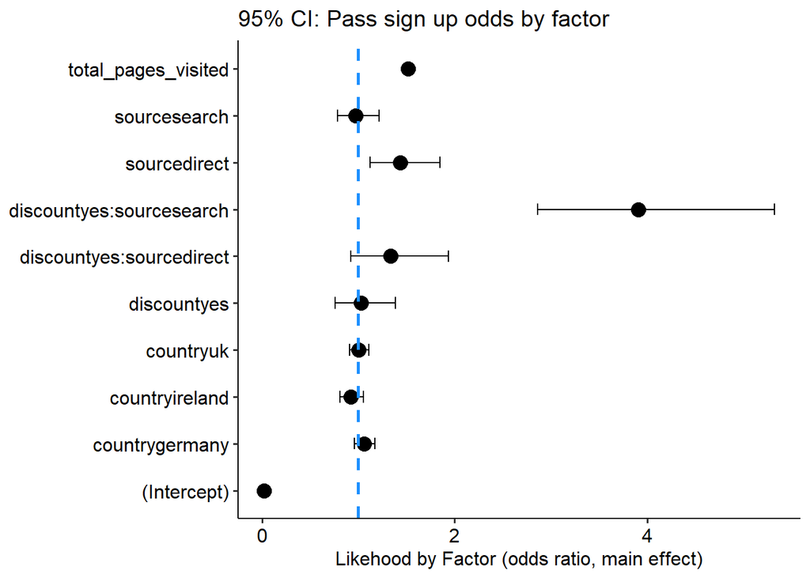

```r
tidy(m5) %>%
  mutate(exp_beta_llci = exp(confint(m5))[, 1],
         exp_beta = exp(estimate),
         exp_beta_ulci = exp(confint(m5))[, 2]) %>%
  select(term, estimate, exp_beta_llci, exp_beta, exp_beta_ulci) %>%
  ggplot(aes(x = term,
             y = exp_beta,
             ymin = exp_beta_llci,
             ymax = exp_beta_ulci)) +
  geom_point(size = 4) +
  geom_errorbar(width = 0.25) +

  geom_hline(yintercept = 1, linetype = "dashed",
                    size = 1, color = "dodgerblue") +
  labs(title = "95% CI: Pass sign up odds by factor",
       x = NULL,
       y = "Likehood by Factor (odds ratio, main effect)") +
  coord_flip() +
  theme_pubr()
```

Discount yes and source search interaction has the highest odds ratio]

# Question-14) Use model m5 to predict the conversion probabilities for each user in the data set. Store these probabilities in the data set, in a variable called base_prob. What is the mean value of base_prob?

```r
ecommerce$base_probability <- predict(
  m5,
  ecommerce,
  type = "response"
)

head(ecommerce)
```

```
##   discount conversion source total_pages_visited visit_duration country
## 1       no         no direct                   3      179.50673  france
## 2       no         no direct                   6      356.98638 germany
## 3       no         no direct                   3      181.38014      uk
## 4       no         no direct                   6      368.17220      uk
## 5       no         no direct                   7      408.97933 germany
## 6       no         no direct                   1       61.15206 germany
##   base_probability
## 1       0.08725431
## 2       0.26111582
## 3       0.08738124
## 4       0.25052005
## 5       0.34899840
## 6       0.04213457
```

```r
mean(ecommerce$base_probability)
```

```
## [1] 0.1759163
```

The mean value of the base probability is 0.1759163

# Question-15) Calculate an indicator variable for whether individuals will convert or not, based on their predicted probabilities from the previous task, using a threshold value of 0.5. Call this variable pred_conversion. How many users so we predict to convert?

```r
ecommerce$pred_conversion <- 1 * (ecommerce$base_probability >= 0.5)
head(ecommerce)
```

```
##   discount conversion source total_pages_visited visit_duration country
## 1       no         no direct                   3      179.50673  france
## 2       no         no direct                   6      356.98638 germany
## 3       no         no direct                   3      181.38014      uk
## 4       no         no direct                   6      368.17220      uk
## 5       no         no direct                   7      408.97933 germany
## 6       no         no direct                   1       61.15206 germany
##   base_probability pred_conversion
## 1       0.08725431               0
## 2       0.26111582               0
## 3       0.08738124               0
## 4       0.25052005               0
## 5       0.34899840               0
## 6       0.04213457               0
```

```r
table(ecommerce$conversion, ecommerce$pred_conversion)
```

```
##
##           0     1
##   no  20190   450
##   yes  3498   908
```

# Question-16) What is the accuracy or hit rate?

```r
(20190+908)/(20190+450+908+3498)
```

```
## [1] 0.84237
```

The accuracy is 84.23%

# Question-17) What is the area under the curve?

```r
roccurve <- roc(ecommerce$conversion,
              ecommerce$base_probability)
roccurve$auc
```

```
## Area under the curve: 0.7748
```

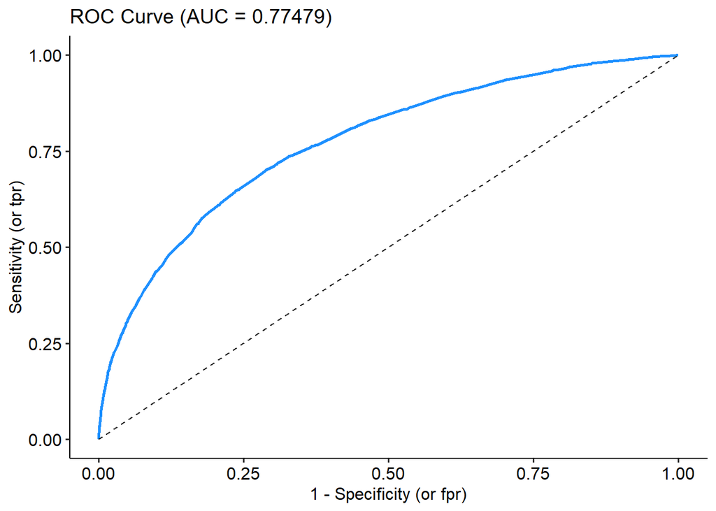

```r
ggroc(roccurve,
      color = "dodgerblue",
      size = 1,
      legacy.axes = T) +
  geom_segment(x = 0, y = 0, xend = 1, yend = 1, linetype = 2, alpha  =  0.01) +
  theme_pubr() +
  labs(title = sprintf("ROC Curve (AUC = %.5f)", roccurve$auc),
       x = "1 - Specificity (or fpr)",
       y = "Sensitivity (or tpr)")
```

The area under the curve is 77.49%

# Question-18) Predict new probabilities under a hypothetical scenario that the values variable total_pages_visited were increased by one unit (i.e., one page) for all users. Store these probabilities in the data set, in a variable called new_prob. What is the mean value of new_prob?

```r
ecommerce_new <- ecommerce
ecommerce_new$total_pages_visited <- ecommerce_new$total_pages_visited+1
ecommerce_new$new_prob <- predict(m5, ecommerce_new, type = "response")
```

```r
mean(ecommerce_new$new_prob)
```

```
## [1] 0.2306219
```

```r
mean(ecommerce_new$base_probability)
```

```
## [1] 0.1759163
```

The mean value of new probabilities is 0.23

# Question-19) Calculate the lift metric for the hypothetical scenario from the previous task (i.e., Task 18)

```r
(mean(ecommerce_new$new_prob) - mean(ecommerce_new$base_probability))/mean(ecommerce_new$base_probability)
```

```
## [1] 0.310975
```

The lift metric ratio is 31%